# White Wine Quality Exploration by Archit Goel

> This report explores the white wine quality dataset. The dataset consists details about chemical properties and a quality rating for 4898 wine samples.

# Univariate Plots Section

```
## [1] 4898   13
```

> The dataset consists of 4898 rows and 13 colummns. First column is the serial number for the wine samples, followed by 11 columns of various chemical properties and the last column contains the quality rating for the wine sample.

```
## 'data.frame':    4898 obs. of  13 variables:
##  $ X                   : int  1 2 3 4 5 6 7 8 9 10 ...
##  $ fixed.acidity       : num  7 6.3 8.1 7.2 7.2 8.1 6.2 7 6.3 8.1 ...
##  $ volatile.acidity    : num  0.27 0.3 0.28 0.23 0.23 0.28 0.32 0.27 0.3 0.22 ...
##  $ citric.acid         : num  0.36 0.34 0.4 0.32 0.32 0.4 0.16 0.36 0.34 0.43 ...
##  $ residual.sugar      : num  20.7 1.6 6.9 8.5 8.5 6.9 7 20.7 1.6 1.5 ...
##  $ chlorides           : num  0.045 0.049 0.05 0.058 0.058 0.05 0.045 0.045 0.049 0.044 ...
##  $ free.sulfur.dioxide : num  45 14 30 47 47 30 30 45 14 28 ...
##  $ total.sulfur.dioxide: num  170 132 97 186 186 97 136 170 132 129 ...
##  $ density             : num  1.001 0.994 0.995 0.996 0.996 ...
##  $ pH                  : num  3 3.3 3.26 3.19 3.19 3.26 3.18 3 3.3 3.22 ...
##  $ sulphates           : num  0.45 0.49 0.44 0.4 0.4 0.44 0.47 0.45 0.49 0.45 ...
##  $ alcohol             : num  8.8 9.5 10.1 9.9 9.9 10.1 9.6 8.8 9.5 11 ...
##  $ quality             : int  6 6 6 6 6 6 6 6 6 6 ...
```

```
##        X        fixed.acidity    volatile.acidity  citric.acid
##  Min.   :   1   Min.   : 3.800   Min.   :0.0800   Min.   :0.0000
##  1st Qu.:1225   1st Qu.: 6.300   1st Qu.:0.2100   1st Qu.:0.2700
##  Median :2450   Median : 6.800   Median :0.2600   Median :0.3200
##  Mean   :2450   Mean   : 6.855   Mean   :0.2782   Mean   :0.3342
##  3rd Qu.:3674   3rd Qu.: 7.300   3rd Qu.:0.3200   3rd Qu.:0.3900
##  Max.   :4898   Max.   :14.200   Max.   :1.1000   Max.   :1.6600
##  residual.sugar     chlorides       free.sulfur.dioxide
##  Min.   : 0.600   Min.   :0.00900   Min.   :  2.00
##  1st Qu.: 1.700   1st Qu.:0.03600   1st Qu.: 23.00
##  Median : 5.200   Median :0.04300   Median : 34.00
##  Mean   : 6.391   Mean   :0.04577   Mean   : 35.31
##  3rd Qu.: 9.900   3rd Qu.:0.05000   3rd Qu.: 46.00
##  Max.   :65.800   Max.   :0.34600   Max.   :289.00
##  total.sulfur.dioxide    density             pH          sulphates
##  Min.   :  9.0        Min.   :0.9871   Min.   :2.720   Min.   :0.2200
##  1st Qu.:108.0        1st Qu.:0.9917   1st Qu.:3.090   1st Qu.:0.4100
##  Median :134.0        Median :0.9937   Median :3.180   Median :0.4700
##  Mean   :138.4        Mean   :0.9940   Mean   :3.188   Mean   :0.4898
##  3rd Qu.:167.0        3rd Qu.:0.9961   3rd Qu.:3.280   3rd Qu.:0.5500
##  Max.   :440.0        Max.   :1.0390   Max.   :3.820   Max.   :1.0800
##     alcohol         quality
##  Min.   : 8.00   Min.   :3.000
##  1st Qu.: 9.50   1st Qu.:5.000
##  Median :10.40   Median :6.000
##  Mean   :10.51   Mean   :5.878
##  3rd Qu.:11.40   3rd Qu.:6.000
##  Max.   :14.20   Max.   :9.000
```

> We may want to recode quality into a categorical variables, and consider recoding the current values into quality buckets such as low, below average, average, above average, and high quality.

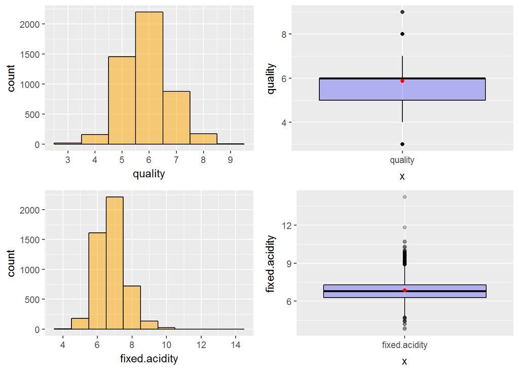

> Quality ratings are majorly concentrated between 5 to 7 (inclusive) and all quality ratings are between 3 to 9 (inclusive). For further analysis, quality will be recoded into three buckets - Below average (3,4,5), Average (6), Above average (7,8,9)

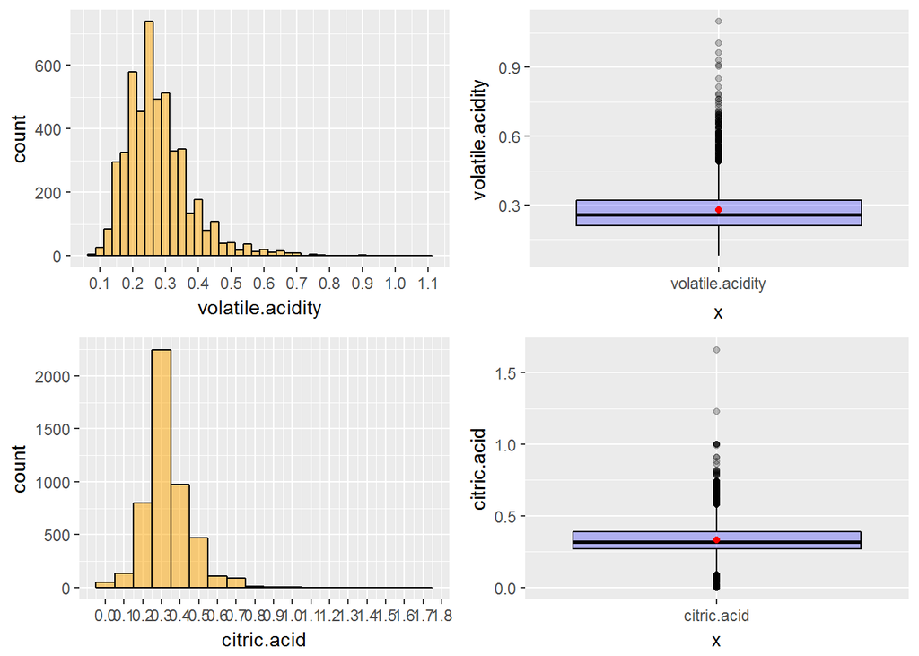

> Variables associated with acidity (i.e. fixed acidity, volatile acidity, citric acid) have a slight positively skewed distribution, with considerable outliers. If the outliers were ignored, then they have a normal distribution

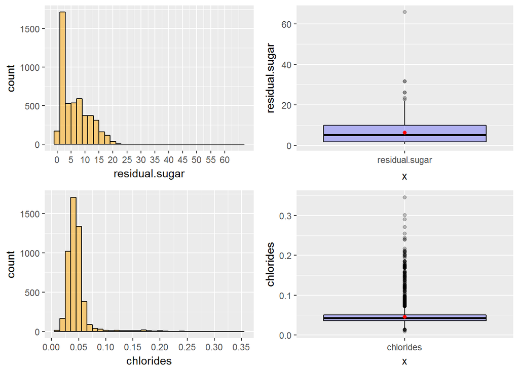

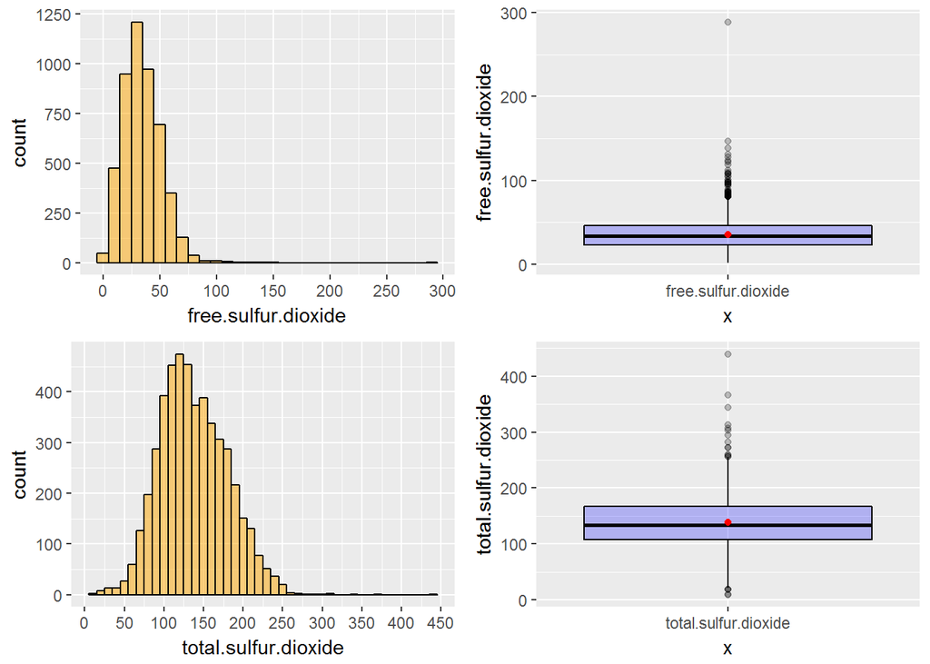

> Residual sugar, chlorides, free sulfur dioxide and total sulfur dioxide have a positively skewed distribution with outliers mostly on the higher side of their value range

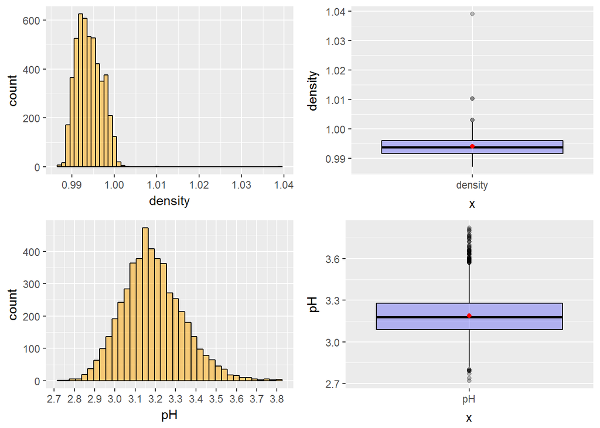

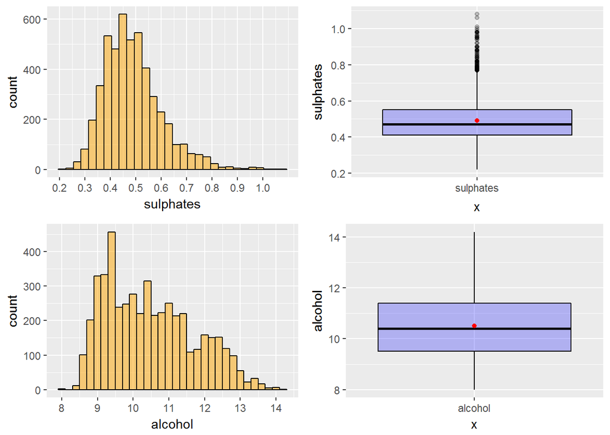

> Density, pH, and sulphates too have some outliers mostly on the larger side Alcohol has an irregular distribution/ shape

> Recode quality into a categorical variable per above decided buckets and name it “quality_cat”

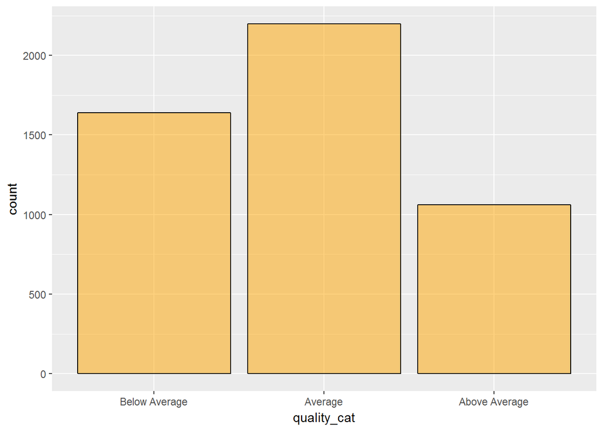

# Univariate Analysis

### What is the structure of your dataset?

> Our dataset has 4898 observations (rows) and 13 variables (columns). We have created an extra variable which is recoded from the quality rating variable

### What is/are the main feature(s) of interest in your dataset?

> The main feature of interest for us is the quality rating of wine samples and we will try to understand which factors affect the quality ratings of the wine

### What other features in the dataset do you think will help support your investigation into your feature(s) of interest?

> Other than quality, it would be interesting to focus on alcohol content and how quality is dependent on the alcohol quantity of the wine. Also it would be interesting to explore other wine properties such as density, residual sugar, and sulphur dioxide content to notice any patterns

### Did you create any new variables from existing variables in the dataset?

> Originally quality was a discrete variable, which we recoded for further analysis and converted it into a categorical variable. The new recoded vairable for quality (i.e. “quality_cat”) has 3 values: Below average (rating of 3,4,5), average (rating of 6), and above average (rating of 7,8,9)

### Did you perform any operations on the data to tidy, adjust, or change the form of the data? If so, why did you do this?

> The scale for most of the variable’s histogram was adjusted to report a tidier form of presentation. Quality was recoded for further analysis.

# Bivariate Analysis

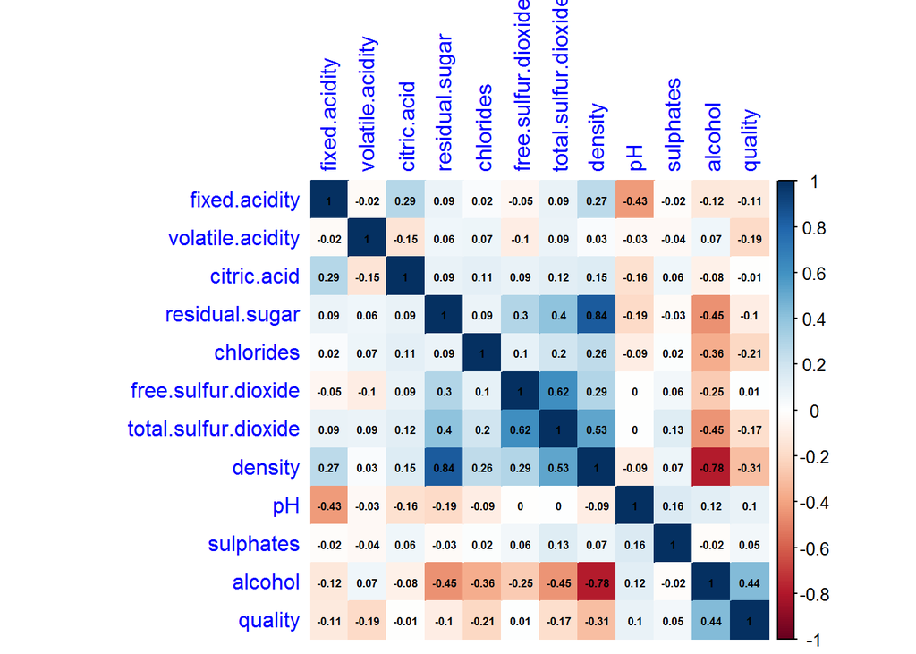

> From the correlation coefficients between all variables we can observe that majoirty of the pairs of variables have a weak correlation (i.e. smaller than 0.3) and some pairs have a moderate correlation (i.e. between 0.3 and 0.7), while only 2 pairs have a strong correlation (i.e. greater than 0.7)

> We would like to further explore the relation for below variable pairs: - quality and alcohol - quality and density - alcohol and density - free sulfur dioxide and total sulfur dioxide - density and residual sugar - density and total sulfur dioxide - alcohol and residual sugar - alcohol and total sulfur dioxide

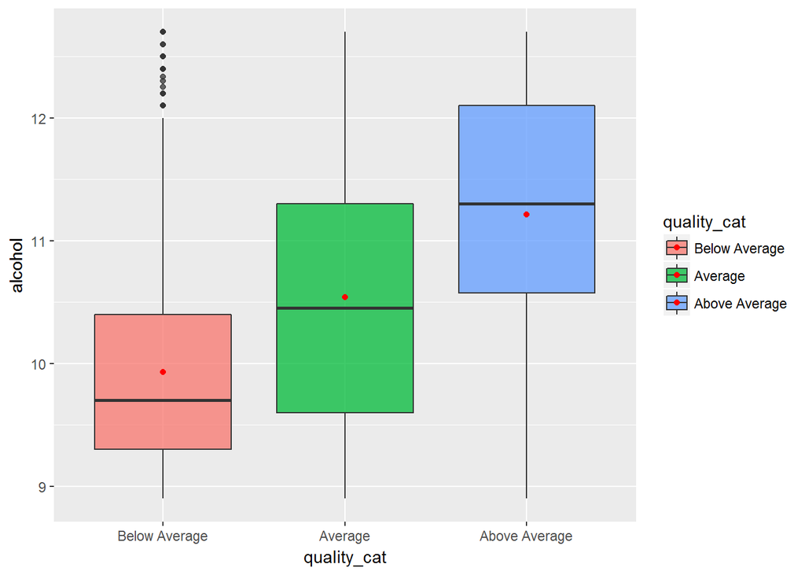

> From the above chart we can easily interpret a relation between alcohol quantity and the wine quality rating. Wines that are rated high in quality tend to have a higher alcohol content

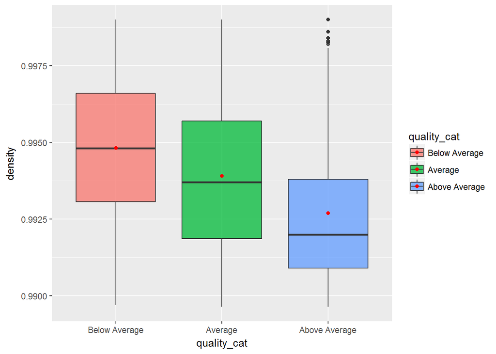

> From the above chart we can interpret that wines that are rated higher in quality tend to have a lower density

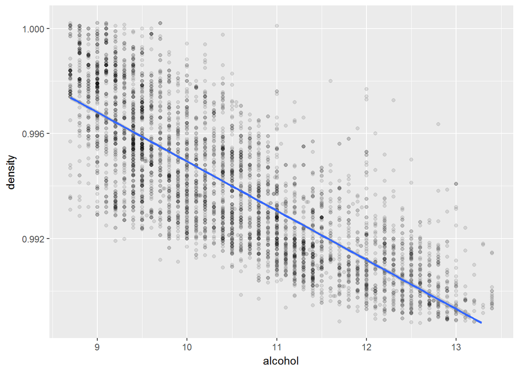

> A strong negative correlation can be observed between acohol content and density of the wine

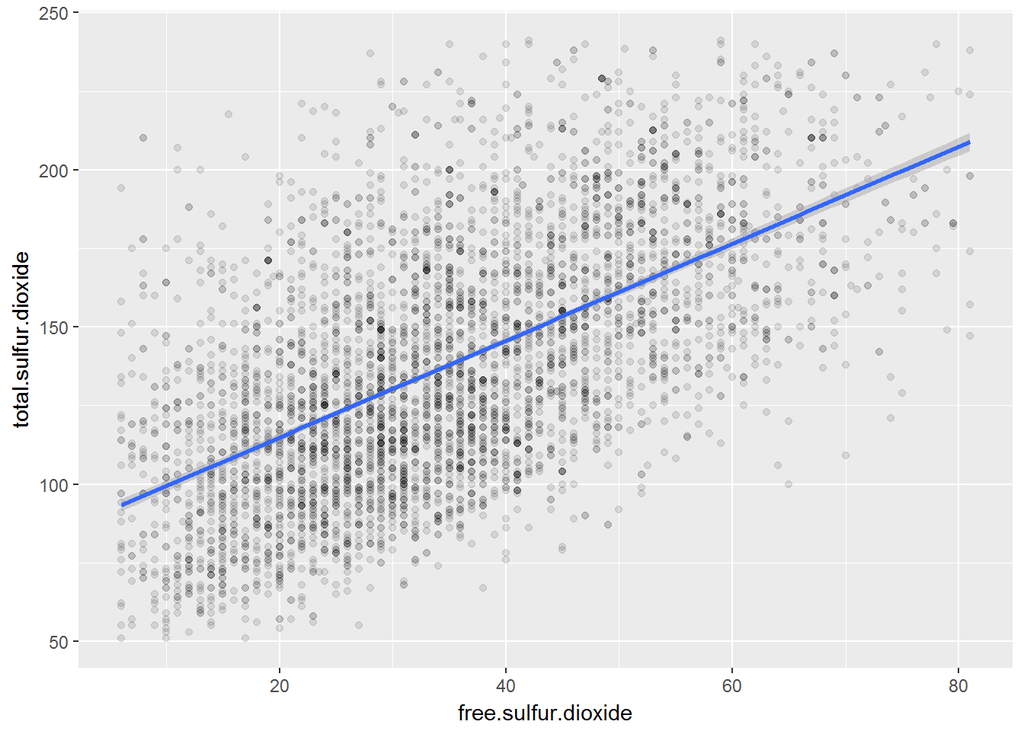

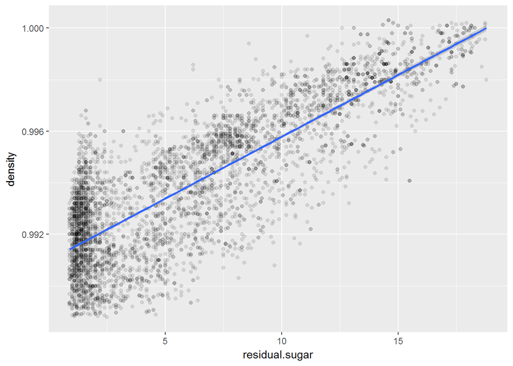

> There is a strong positive correlation between residual sugar and density of the wine

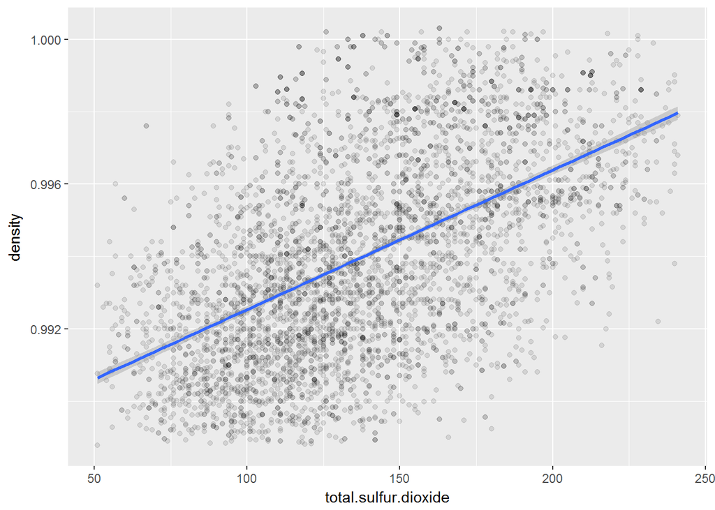

> There exists a moderate positive correlation between density of the wine and the total sulfur dioxide content of the wine

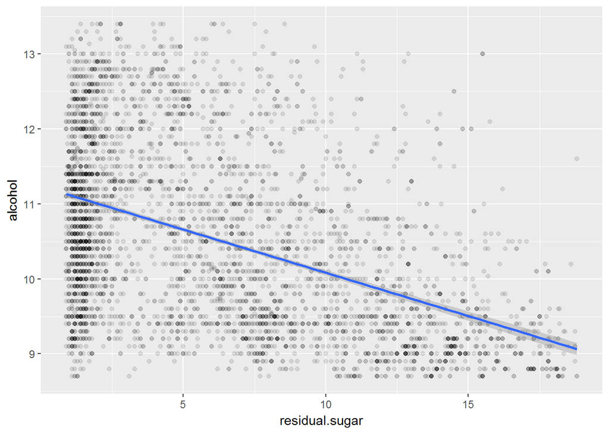

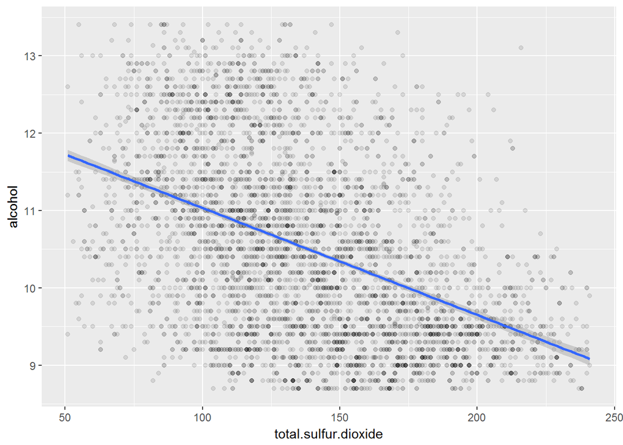

### Talk about some of the relationships you observed in this part of the investigation. How did the feature(s) of interest vary with other features in the dataset?

> As expected alcohol and density had a high negative relation

### Did you observe any interesting relationships between the other features (not the main feature(s) of interest)?

> Other features, such as, residual sugar and total sulfur dioxide were positively related with the density of the wine, and therefore had an indirect negative impact on the quality of the wine

### What was the strongest relationship you found?

> The strongest relation in our dataset was between residual sugar in the wine and density of the wine. This was a positive relation with a correlation factor of 0.84 This is relation looks logical as a higher amount of residuals in any liquid would tend to increase the density of that liquid

# Multivariate Plots Section

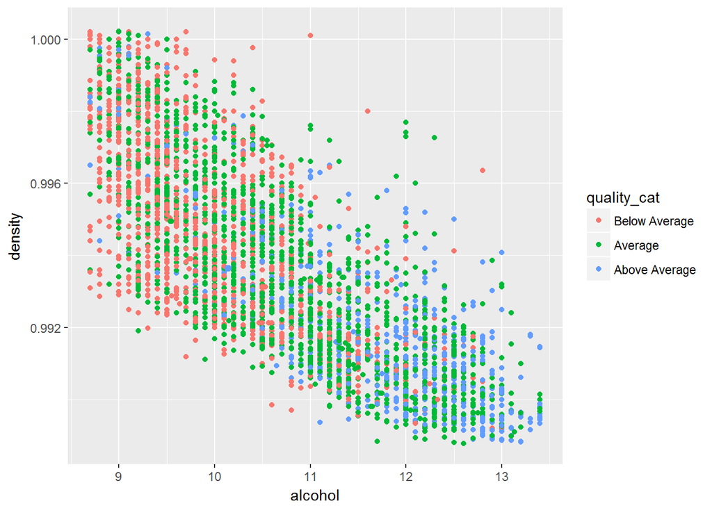

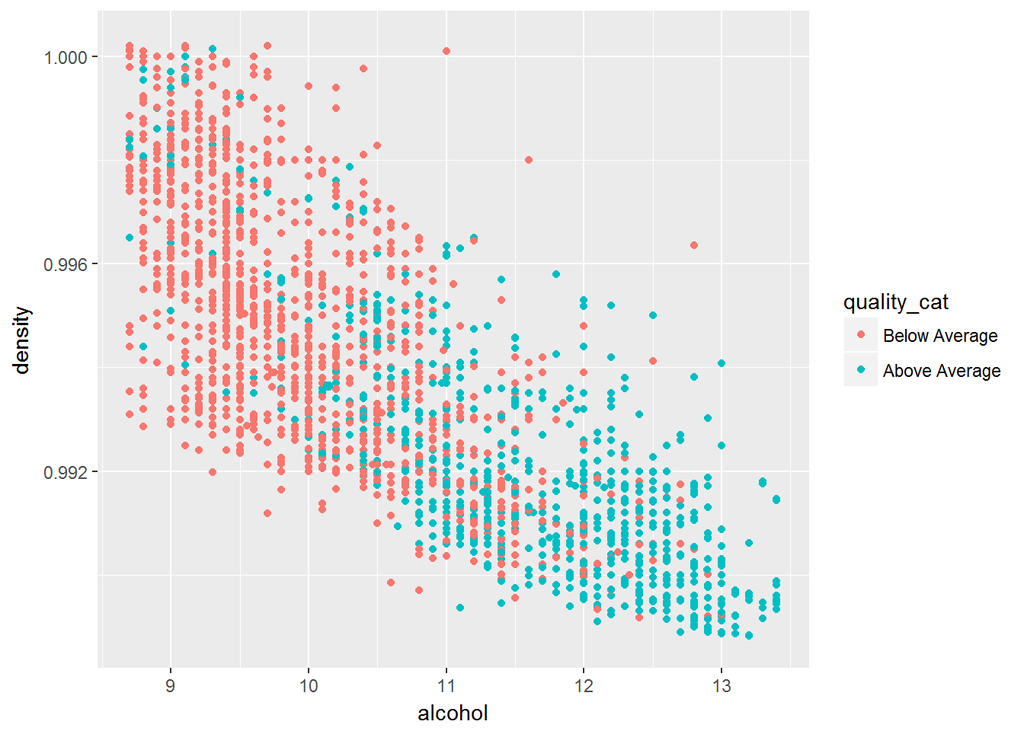

> Majority of our sample wines with ‘Above average’ quality (i.e. wines with quality rating 7, 8, or 9) fall in the bottom right quadrant with low density and high alcohol content

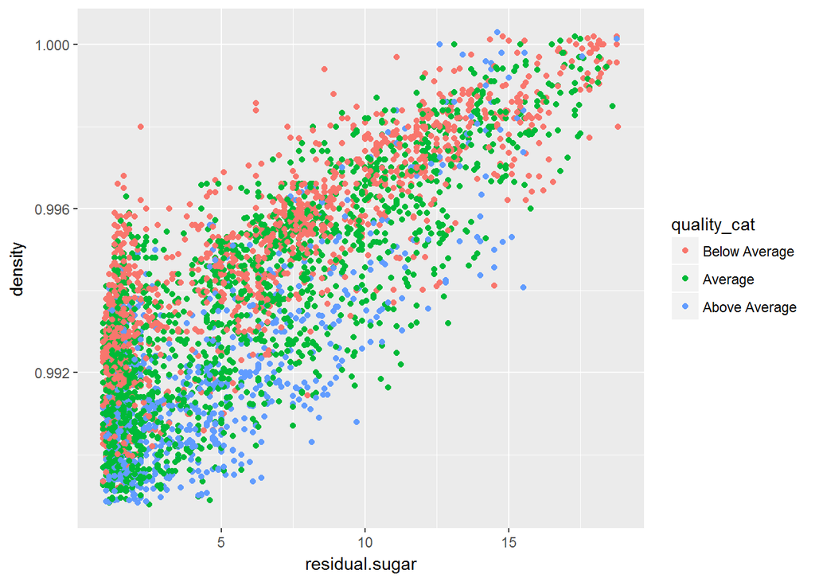

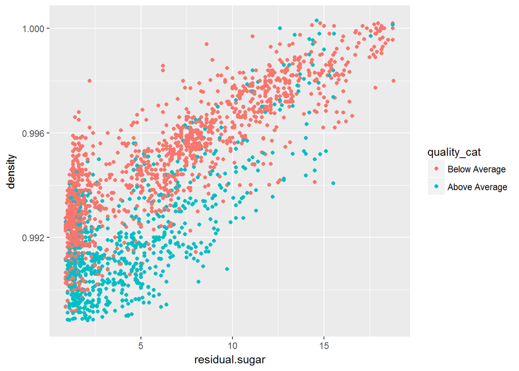

> From the above two charts we can report that a wine sample with ‘above average’ quality is more likely to have a low density and low residual sugar

> We can also abserve that some wine samples have a ‘below average’ quality rating even though they have low residual sugar content. This indicates that having a low density is a more important parameter of an ‘above average’ wine

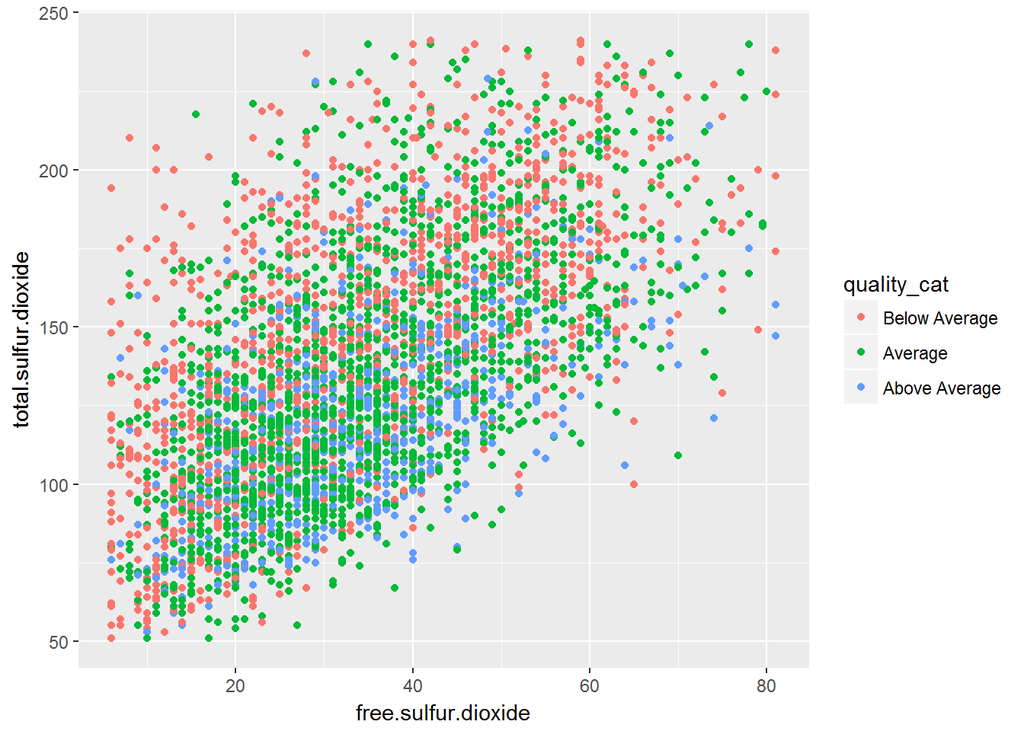

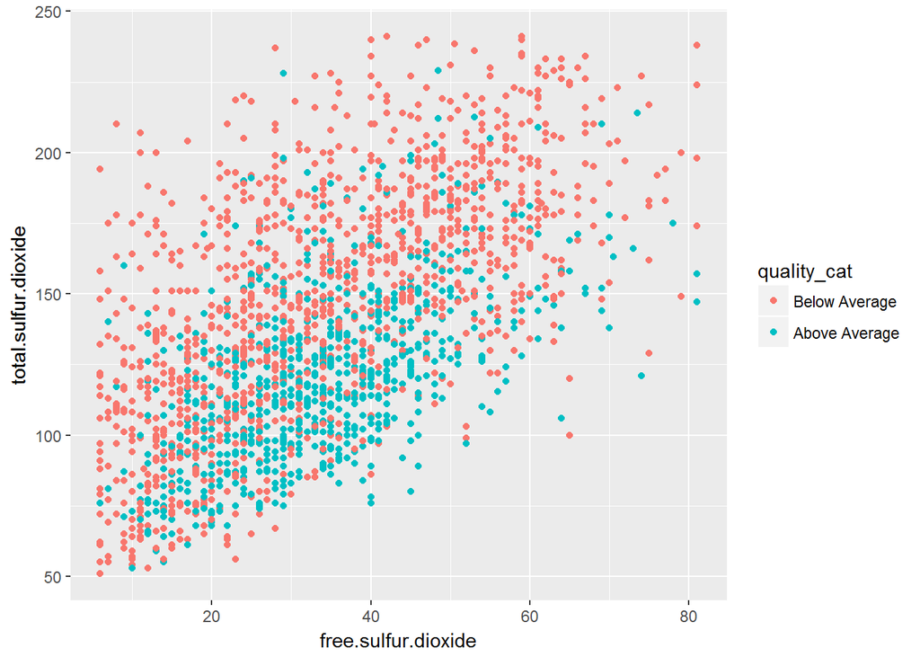

> There is high variance in the above two plots. However, we can observe that majority of the ‘above average’ wines have a lower total sulfur dioxide (less than 150ppm) quantity and an average free sulfur dioxide quantity (~ 20-45 ppm)

# Multivariate Analysis

### Talk about some of the relationships you observed in this part of the investigation. Were there features that strengthened each other in terms of looking at your feature(s) of interest?

> From our multivariate analysis, we can report that the wines with ‘above average’ quality seem to have a combination of low density and high alcohol content, and it is preferable that the wines have low residual sugar

> It was evident that low density could be prioritised over low residual sugar. But having said that, low residual sugar is an important criteria for an ‘above average’ wine quality too

### Were there any interesting or surprising interactions between features?

> From our bivariate analysis, we knew that density and residual sugar are highly positively correlated with each other. While wine quality was negatively correlated with the density. Which led us to assume that low residual sugar will indirectly be related with good quality wines. However, from our multivariate analysis we can observe that some ‘below average’ wines also have a low residual sugar, hence, indicating that having a low density is a more important parameter of an ‘above average’ wine sample

# Final Plots and Summary

### Plot One

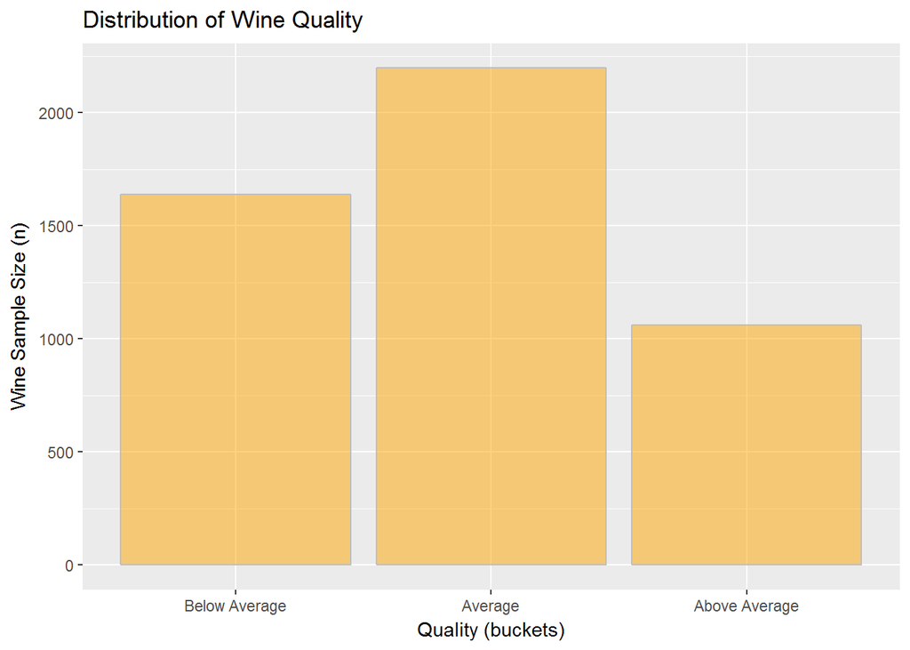

### Description One

> The plot provides a basic distribution of the quality data from the given wine dataset. The buckets were recalculated using the original quality rating data for the purpose of analysis ‘Below average’ corresponds to quality rating of 3,4, or 5 ‘Average’ corresponds to quality rating of 6 ‘Above average’ corresponds to quality rating of 7,8, or 9 We should note that our sample database does not consist of wines with a quality rating of 1,2 or 10

### Plot Two

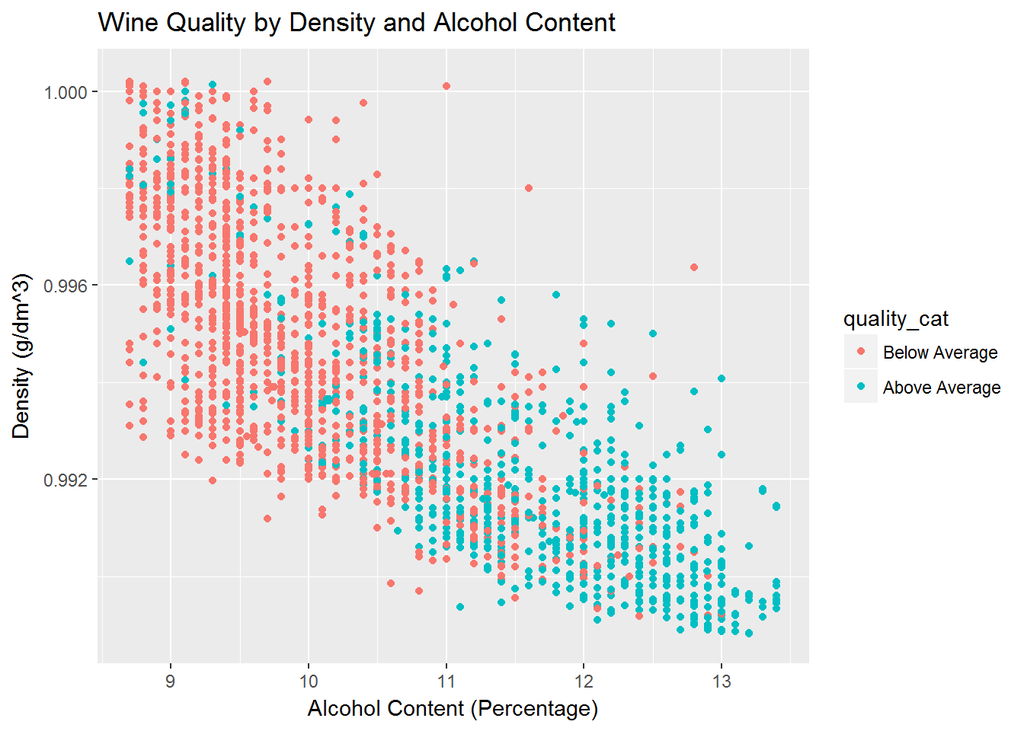

### Description Two

> Density and alcohol have the strongest relation with quality of the wine. While density has a negative co-relation with wine quality, alcohol quantity has a positive co-relation with wine quality We can observe that majority of the wine sample with an ‘Above average’ quality rating (i.e. a rating of 7, 8, or 9) fall in the bottom right quadrant of the plot, indicating that good quality wines have a low density and high alcohol content

### Plot Three

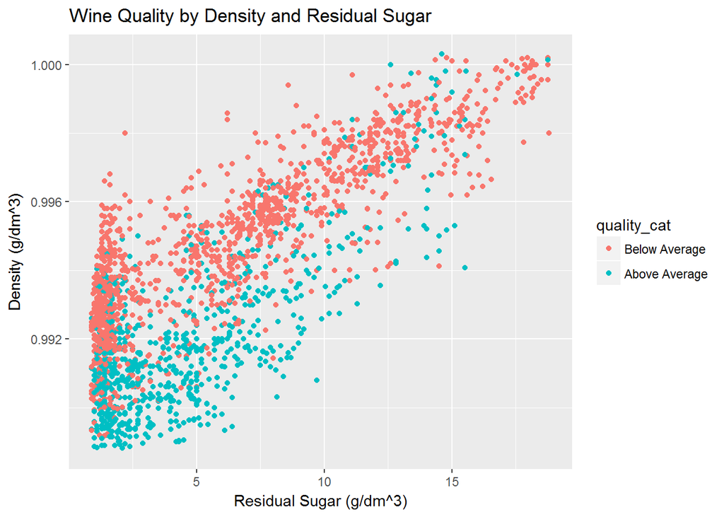

### Description Three

> Density and residual sugar had the strongest co-relation in our analysis. The pair has a co-relation factor of 0.84, which is a strong positive relation. The above plot consists of a distribution of wine quality by density and residual sugar. We can observe from the plot that majority of the ‘Above Average’ wines have a low density and low residual sugar An interesting point in the plot is that a considerable number of ‘Below Average’ wines also have low residual sugar but a high density. This indicates that having a low density is a comparatively more important parameter of an ‘above average’ wine

# Reflection

> We began with understanding the basic distribution of all the variables in our dataset. This helped in noting one limitation of the dataset, i.e. lack of sample with extreme quality ratings. It was noted that majority of the sample has a quality rating of 5, 6, and 7 with very little sample with other quality ratings and no sample with 1, 2, and 10. For further analysis a new variable was created for quality which had quality ratings divided into three buckets

> A correlation matrix between all variables helped us in finding the variable pairs which had a considerable co-relation and were of interest. Our main priority in this step was to identify the primary variables which were highly related with quality of wine. We also explored variables which had a strong/ moderate relation with these primary variables

> However, it must be noted that all the insights are limited by the dataset. One of the limitations of our analysis is that the data was collected from one particular area in Portugal. Also, it does not contain any sample with extreme quality ratings, and a low sample size for very low and very high quality ratings.

> An interesting aspect could be to build a predictive model for wine quality based on the chemical properties in the dataset. It would also be interesting to factor in the price of the wine sample, and explore how the price varies/ depends on the various chemical properties of the wine